# Loan Data Exploration

## by Ola Galal

## Investigation Overview

In this exploration, I wanted to look at the characteristics of loans that could be used to predict their borrower APR. The main focus was on the original loan amount, borrower's Prosper rating, loan term, borrower's stated monthly income.

## Dataset Overview

This data set contains 113,937 loans with 81 variables on each loan, including loan amount, borrower rate (or interest rate), current loan status, borrower income, and many others.

## Borrower APR Frequency Distribution

The distribution of APR looks multimodal. A small peak centered at 0.1, a large peak centered at 0.2. There is also a small peak centered 0.3. Additionally, there is a very shape peak between 0.35 and 0.36. Only very few loans have APR greater than 0.43.

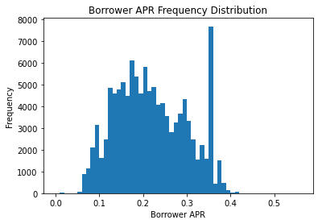

## Listing Categories

It indicates that most of Prosper loans are debt consolidation. And, its followed by not available and other kinds of loans, indicating that Prosper should do a better job to correctly classify its loans.

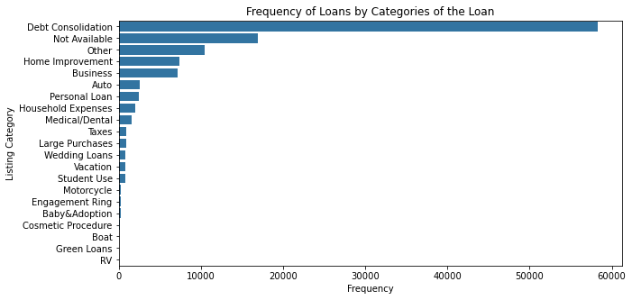

## CurrentCreditLines vs. OpenRevolvingAccounts

The CurrentCreditLines and OpenRevolvingAccounts dimensions are all highly correlated with one another.

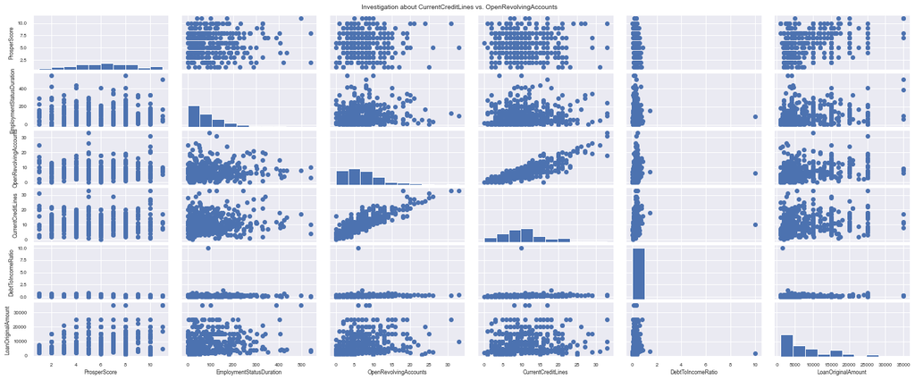

## ProsperScore vs. BorrowerRate

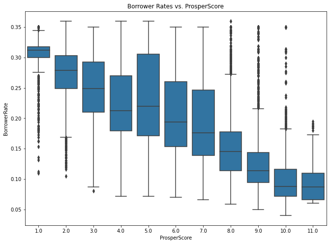

## LoanOriginalAmount vs. BorrowerAPR

The plot show that at different size of the loan amount, the APR has a large range, but the range of APR decrease with the increase of loan amount.

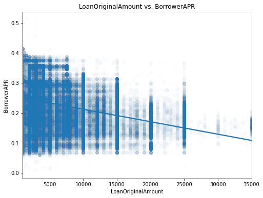

## BorrowerAPR vs. CreditScoreRangeUpper & ProsperScore

There are negative correlation between CreditScoreRangeUpper and BorrowerAPR. And Also from the right-side plot, ProsperScore has negative correlation with BorrowAPR.

[figure not shown]